# CS151: Midterm 2 Exam Question

Date: March 22, 2024; Duration: 1 Hour

This second midterm exam contains 1 question that consist of topics already covered in the class (Functions, Graphics, and Interactive Programs). This is a programming problem, hence, use Visual Studio Code to write and test your program. Ensure that your program is well documented.

Your work must be your own on this exam, and under no conditions should you share your solution with anyone but myself. Failure to abide by these rules will be considered a breach of Willamette’s Honor Code and will result in penalties as set forth by Willamette’s academic honesty policy.

**RULES**

1. This is a totally an open exam. However, if you use any Large Language Model (LLM) such as ChatGPT, you must indicate that at the top of your program file in the portion to indicate where you obtain assistant.
2. You must submit a python file with the name `programemoji.py`. The submission is done by uploading this same file back to the GitHub Classroom repository.
3. Use ONLY the Portable Graphic Library (PGL) taught in the class and provided in the starter code.
4. You must type your *full names* at the top of the program file name `programemoji.py` to indicate that you have read and understand the instructions and agree to abide by them. **Failure to abide by the rules will result in a 0 on the test**.

**Useful info:**

1. *There is no timer function set on this exam to track or monitor the time you have spent or remaining. You’ve got to monitor your time manually to remain within the allowable 1 hour.*
2. *Those with Willamette University official accommodation for extra time for exams could add their time to the 1 hour originally scheduled for the exam. This means that the late submission policy only applies to such a student after the 1 hour + the extra time.*
3. *Make your submission within the 1-hour duration to avoid losing points or scoring 0. You will earn points from different components, which means that you must not complete all the tasks before making your submission.*

**Late Submission Policy**

1. 10 points off if submission is 5 minutes late
2. 20 points off if submission is 15 minutes late
3. 50 points off if submission is 25 minutes late
4. 100 points off if submission is > 25 minutes late

When you are done reading the instructions above, use the link below to accept the exam and download the starter codes from the GitHub Classroom

[Accept Midterm 2 Exam](https://classroom.github.com/a/90YtOjwu)

# PROBLEM

Use the `GOval`, `GLine`, `GRect` and `GPolygon` classes to create a cartoon drawing of a face that looks like an emoji described below:

**Part #1**

1. Draw the emoji face colored with yellow and place it at the center of the window - *5 points*
2. Draw the right and left eyes (both colored black) to be well positioned on the face such that they alighned appropraitely - *10 points*
3. Draw the right and left pupils (both colored white) and position them so that the left pupil align perfectly to the center of the left eye while the right pupil also align perfectly to the center of the right eye - *10 points*
4. Draw the nose (a triable shape) colored black and position it at the center of the face - *10 points*
5. Draw the mouth colored black and place it below the nose and should be well aligned - *15 points*
6. Give a caption *This is an emoji simulation of a pumpkin head!* to the image which should appear directly below the face and colored green. - *10 points*

Once you are done with all these tasks, your program should generate an image that looks like this

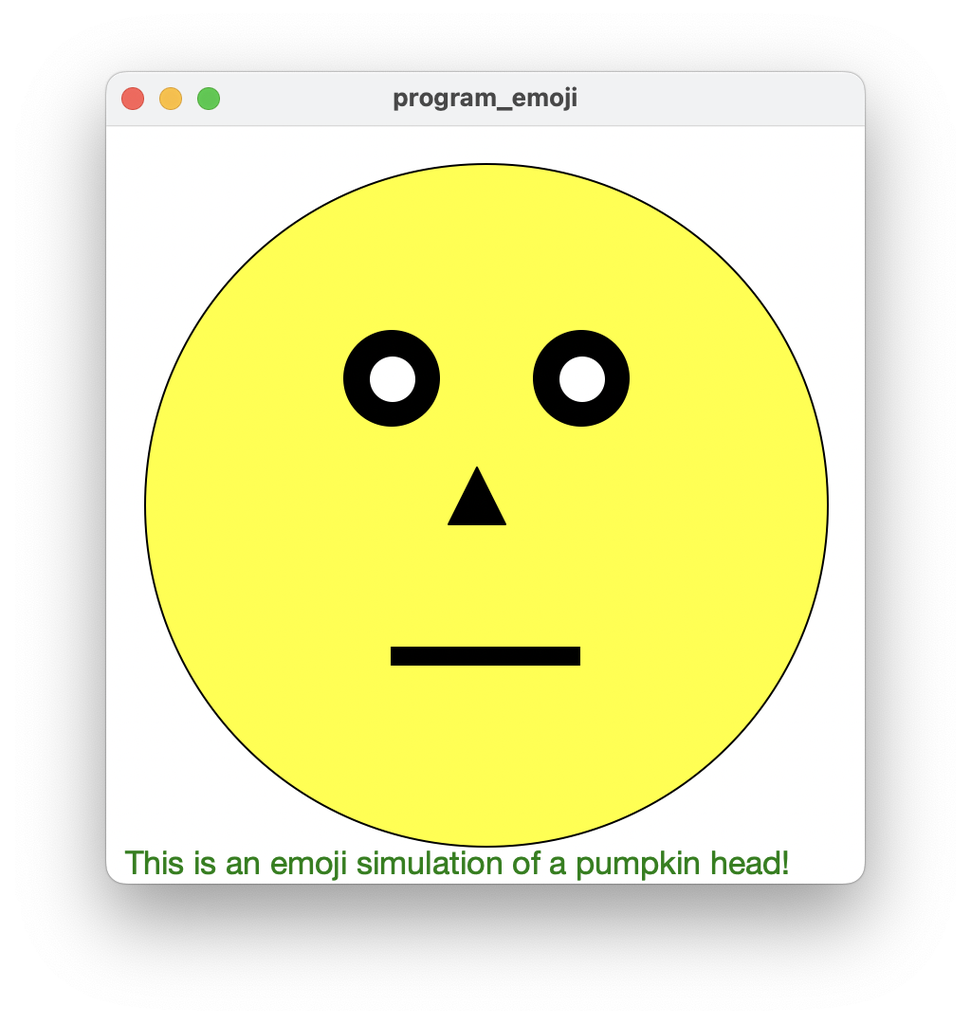

**Part #2**

Once you have this picture, add a callback function for the “mousemove” event so that the pupils in the eyes follow the cursor position. For example, if you move the cursor to the lower right side of the screen, the pupils should shift so that they appear to be looking at that point, as shown in the annimation below - *40 points*

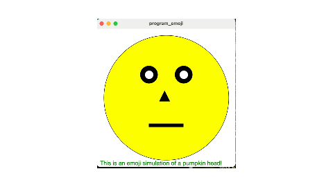